# Chapter3_results

L. Ricolfi

2022-11-25

# 1 Intro

**Project title:** Maternal PFAS transfer in birds - A systematic review and meta-analysis

In this document I provide the **preliminary** results of my systematic review and meta-analysis on maternal PFAS transfer in wild birds

```r
library(tidyverse)
library(readr)
library(ape, curl)
library(rotl)
library(here)
library(dm)
library(dplyr)
library(metafor)
library(orchaRd)
```

# 2 Data Model

In this project I used a relational database as data model. The extracted data from the included studies is stored in 6 data tables organized by type of data.

The following diagram shows how the 6 data tables are related each other and the keys that make the connections possible.

- **me** = measurements data table. It includes statistical data for effect sizes calculation
- **pfas** = data related to the pfas types
- **sa** = data related to the sample types
- **co** = data related to the cohorts
- **sp** = data related to the bird species
- **st** = data related to the studies

[interactive chart not shown]

## 2.1 Meta-data

Please refer to the file “chapter3_metadata.png”.

# 3 Functions

The `lnRR_func` function is here used to calculate a log response ratio (lnRR) adjusted for small sample sizes. In addition, this formula accounts for correlated samples. For more details, see *Doncaster and Spake (2018) Correction for bias in meta-analysis of little-replicated studies. Methods in Ecology and Evolution; 9:634-644*

lnRR_func <- function(mean_A, n_A, mean_P, n_P, aCV2a, aCV2p){ lnRR <- log(mean_P/mean_A) + 0.5 * ((aCV2p/n_P) - (aCV2a/n_A))  
lnRR }

# 4 Phylogenetic tree

The following is the phylogenetic tree of the bird species

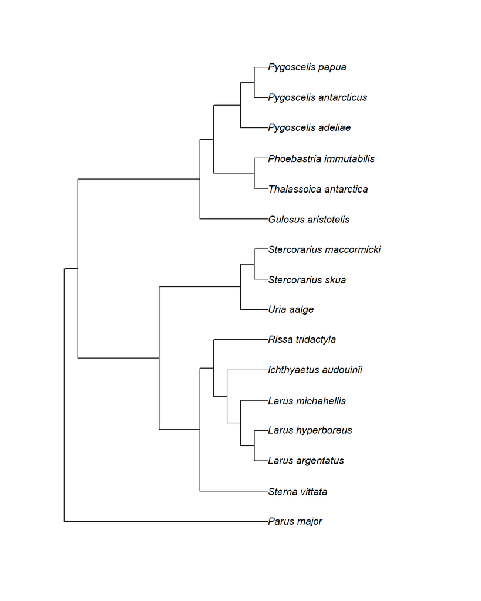

# 5 Calculate Effect sizes

The following graph shows the distribution of effect sizes

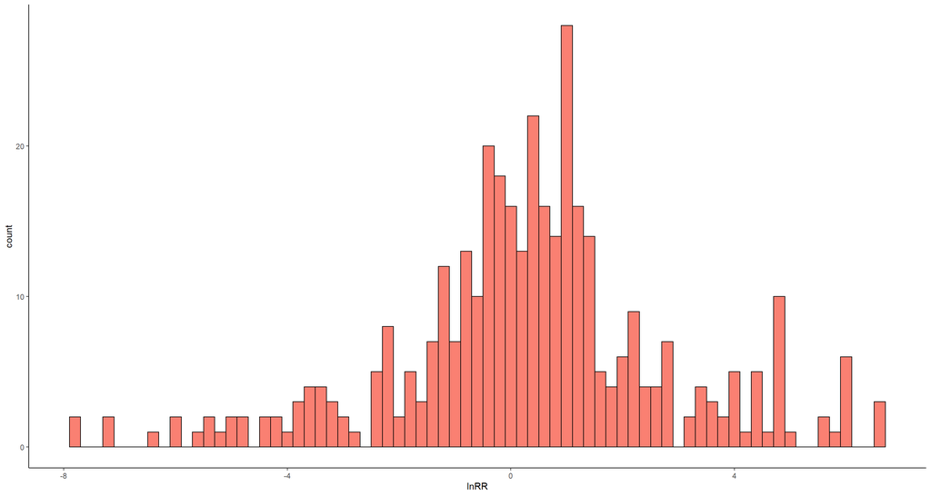

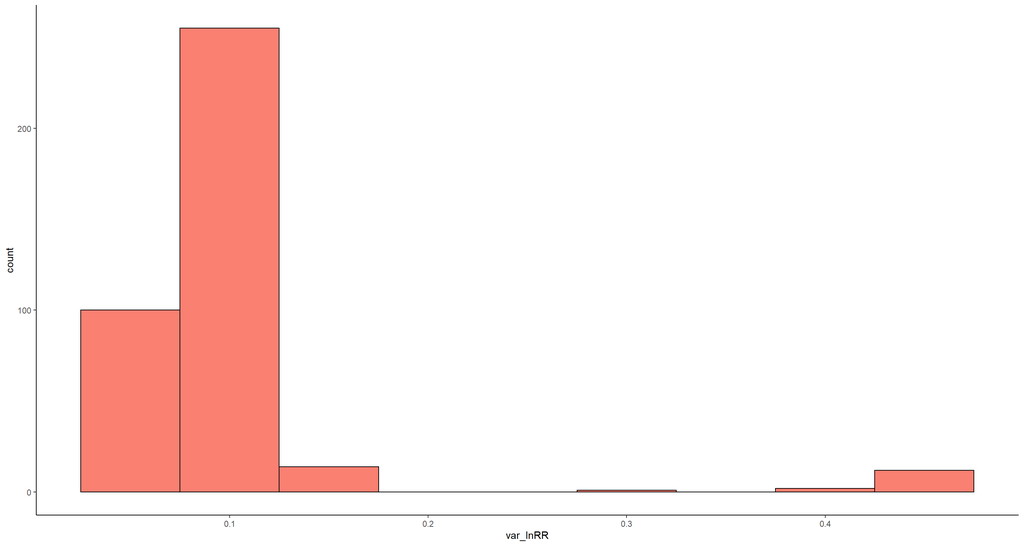

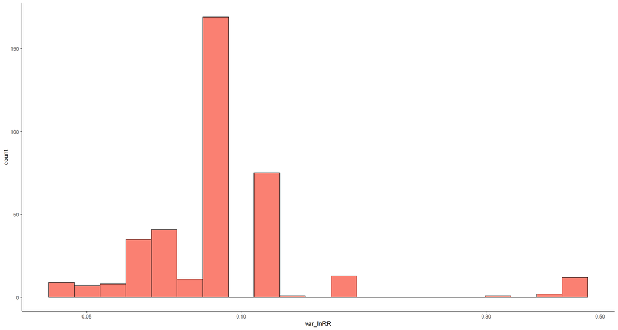

# 6 Meta-analysis

## 6.1 MA with variance

```
##
## Multivariate Meta-Analysis Model (k = 371; method: REML)
##
##    logLik   Deviance        AIC        BIC       AICc
## -859.6293  1719.2585  1725.2585  1736.9990  1725.3241
##
## Variance Components:
##
##             estim    sqrt  nlvls  fixed    factor
## sigma^2.1  5.8805  2.4250    371     no     es_ID
## sigma^2.2  0.2904  0.5389     13     no  study_ID
##
## Test for Heterogeneity:
## Q(df = 370) = 25229.7066, p-val < .0001
##
## Model Results:
##
## estimate      se    tval   df    pval    ci.lb   ci.ub
##   0.3232  0.2253  1.4349  370  0.1522  -0.1197  0.7662
##
## ---
## Signif. codes:  0 '***' 0.001 '**' 0.01 '*' 0.05 '.' 0.1 ' ' 1
```

```
##    I2_Total    I2_es_ID I2_study_ID
##   98.607275   93.966731    4.640544
```

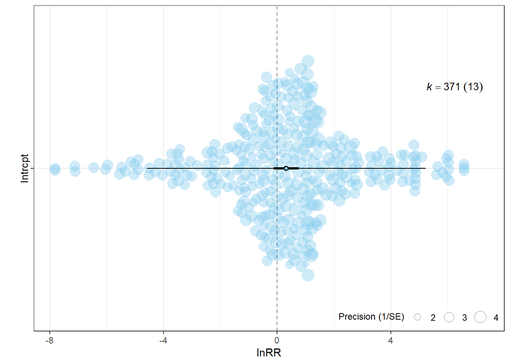

## 6.2 Moderators

Let’s add **pfas type** as moderator in the model

```
##
## Multivariate Meta-Analysis Model (k = 371; method: REML)
##
##    logLik   Deviance        AIC        BIC       AICc
## -858.9911  1717.9822  1725.9822  1741.6362  1726.0918
##
## Variance Components:
##
##             estim    sqrt  nlvls  fixed    factor
## sigma^2.1  0.1478  0.3844     25     no   pfas_ID
## sigma^2.2  5.7630  2.4006    371     no     es_ID
## sigma^2.3  0.2532  0.5032     13     no  study_ID
##
## Test for Heterogeneity:
## Q(df = 370) = 25229.7066, p-val < .0001
##
## Model Results:
##
## estimate      se    tval   df    pval    ci.lb   ci.ub
##   0.3464  0.2368  1.4629  370  0.1443  -0.1192  0.8120
##
## ---
## Signif. codes:  0 '***' 0.001 '**' 0.01 '*' 0.05 '.' 0.1 ' ' 1
```

```
##    I2_Total  I2_pfas_ID    I2_es_ID I2_study_ID
##   98.605705    2.363696   92.192096    4.049913
```

Let’s add **progeny’ sample type** as moderator in the model

```
##
## Multivariate Meta-Analysis Model (k = 371; method: REML)
##
##    logLik   Deviance        AIC        BIC       AICc
## -677.8417  1355.6834  1363.6834  1379.3374  1363.7930
##
## Variance Components:
##
##             estim    sqrt  nlvls  fixed         factor
## sigma^2.1  7.4764  2.7343      5     no  sample_type_P
## sigma^2.2  1.9325  1.3902    371     no          es_ID
## sigma^2.3  1.0415  1.0206     13     no       study_ID
##
## Test for Heterogeneity:
## Q(df = 370) = 25229.7066, p-val < .0001
##
## Model Results:
##
## estimate      se     tval   df    pval    ci.lb   ci.ub
##  -0.4656  1.2685  -0.3671  370  0.7138  -2.9600  2.0287
##
## ---
## Signif. codes:  0 '***' 0.001 '**' 0.01 '*' 0.05 '.' 0.1 ' ' 1
```

```
##         I2_Total I2_sample_type_P         I2_es_ID      I2_study_ID
##        99.172887        70.949538        18.339470         9.883879
```

## 6.3 **Intercept meta-analytical model**

### 6.3.1 Determine the random effect structure

```
##
## Multivariate Meta-Analysis Model (k = 371; method: REML)
##
##    logLik   Deviance        AIC        BIC       AICc
## -858.9911  1717.9822  1727.9822  1747.5497  1728.1471
##
## Variance Components:
##
##             estim    sqrt  nlvls  fixed      factor
## sigma^2.1  0.2532  0.5032     13     no    study_ID
## sigma^2.2  0.0000  0.0001     16     no  species_ID
## sigma^2.3  0.1478  0.3844     25     no     pfas_ID
## sigma^2.4  5.7630  2.4006    371     no       es_ID
##
## Test for Heterogeneity:
## Q(df = 370) = 25229.7066, p-val < .0001
##
## Model Results:
##
## estimate      se    tval   df    pval    ci.lb   ci.ub
##   0.3464  0.2368  1.4629  370  0.1443  -0.1192  0.8120
##
## ---
## Signif. codes:  0 '***' 0.001 '**' 0.01 '*' 0.05 '.' 0.1 ' ' 1
```